# My First Report

Author

## Welcome to your practice report

This is a **Quarto** document. It mixes prose text with R code and output. When you render it, Quarto runs the code below and builds a finished HTML page.

Change `author: "Your Name"` in the header above to your own name, then render this file.

## Packages

Load every package the report uses once, at the top: the tidyverse for data and charts, `tidymodels` for modelling, and `medicaldata` for example datasets.

```r
library(tidyverse)
library(tidymodels)
library(medicaldata)
```

## A first look at the data

`data/patients.csv` is a small practice dataset of 12 synthetic patients, from [`ehsanx/HDSx-workspace`](https://github.com/ehsanx/HDSx-workspace/blob/7e3d2f65348f3ac689be41dfaefb7eaf1c04fb2a/data/patients.csv). The code chunk below reads it and shows the first few rows.

```r
patients <- read.csv("data/patients.csv")
head(patients)
```

```
  id age sex region systolic_bp diabetes
1  1  54   F  North         128       no
2  2  61   M  North         141      yes
3  3  47   F  South         119       no
4  4  72   M   East         150      yes
5  5  38   F   West         112       no
6  6  59   M  South         134       no
```

## A first chart

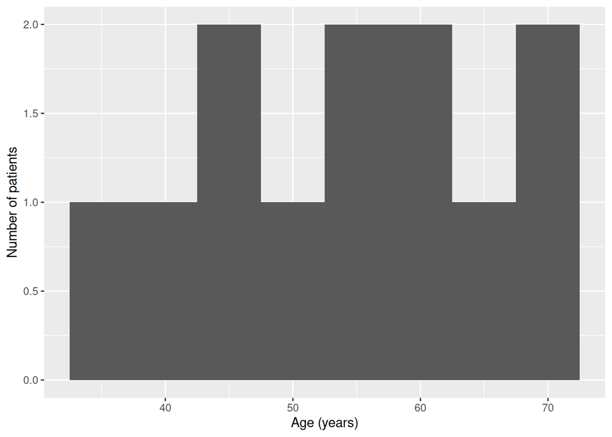

```r
ggplot(patients, aes(x = age)) +
  geom_histogram(binwidth = 5) +
  labs(x = "Age (years)", y = "Number of patients")
```

## A second chart

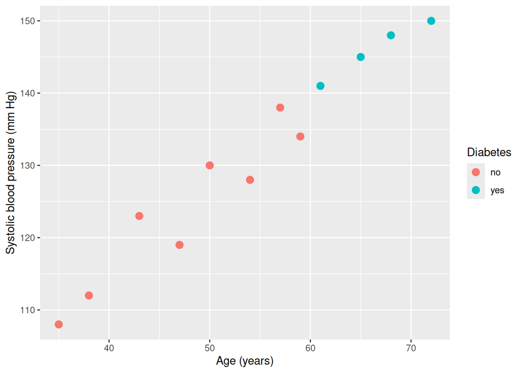

```r
ggplot(patients, aes(x = age, y = systolic_bp, colour = diabetes)) +
  geom_point(size = 3) +
  labs(x = "Age (years)", y = "Systolic blood pressure (mm Hg)",
       colour = "Diabetes")
```

## A medicaldata dataset

`medicaldata` has 15 medical datasets to explore, each described on the [package website](https://higgi13425.github.io/medicaldata/reference/).

**Note**

The website also lists a few newer datasets that the installed version (0.2.0, from CRAN) doesn’t have yet. Run `data(package = "medicaldata")` to see the ones you can load.

To get the newer datasets too, install the development version from GitHub in the R terminal, then restart R:

```r
remotes::install_github("higgi13425/medicaldata")
```

`covid_testing` holds deidentified COVID-19 test results from 2020.

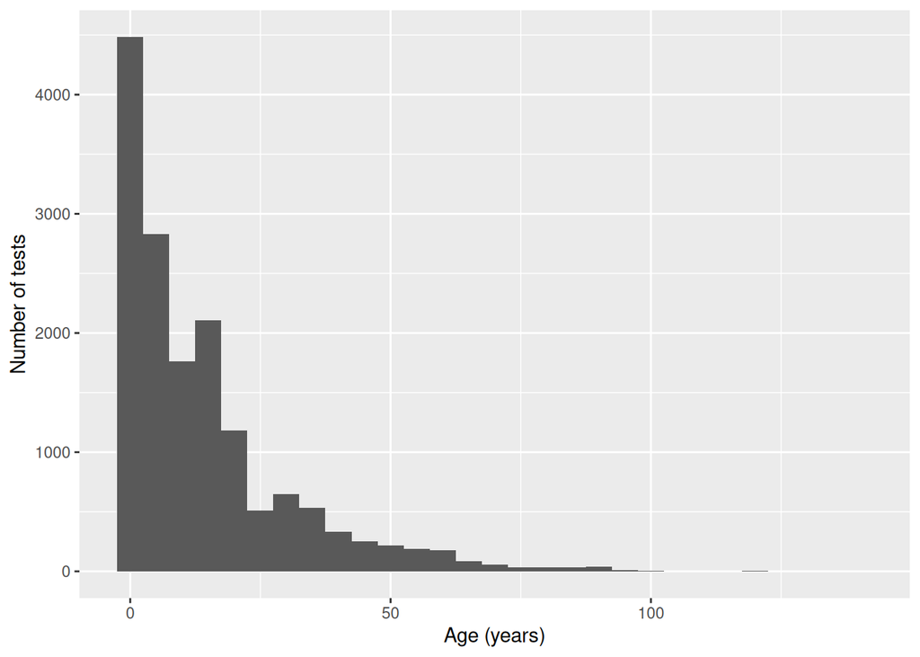

```r
ggplot(covid_testing, aes(x = age)) +
  geom_histogram(binwidth = 5) +
  labs(x = "Age (years)", y = "Number of tests")
```

## A quick model

`licorice_gargle` comes from a randomised trial (Ruetzler et al., 2013) where patients gargled either licorice or sugar water before surgery and were asked about sore throat afterwards. We fit a logistic regression to compare the odds of a sore throat 30 minutes after surgery. An odds ratio below 1 means fewer sore throats with licorice.

```r
licorice <- licorice_gargle |>
  mutate(
    gargle = factor(treat, levels = c(0, 1), labels = c("sugar", "licorice")),
    sore_throat = factor(pacu30min_throatPain > 0, levels = c(FALSE, TRUE),
                         labels = c("no", "yes"))
  ) |>
  drop_na(sore_throat)

logistic_reg() |>
  fit(sore_throat ~ gargle, data = licorice) |>
  tidy(exponentiate = TRUE, conf.int = TRUE)
```

```
# A tibble: 2 × 7
  term           estimate std.error statistic p.value conf.low conf.high
  <chr>             <dbl>     <dbl>     <dbl>   <dbl>    <dbl>     <dbl>
1 (Intercept)       0.568     0.193     -2.93 0.00337    0.386     0.824
2 garglelicorice    0.408     0.305     -2.93 0.00334    0.221     0.736
```